# Les circuits quantiques

Les [circuits quantiques](https://fr.wikipedia.org/wiki/Porte_quantique) sont, comme leur nom l'indique, des circuits, une structure siminlaire à des circuits électriques conçus au collège.

Ils sont composés de briques de base que l'on a déjà vues : les portes quantiques. Il faut savoir que les portes quantiques sont des circuits quantiques.

On définit un circuit quantique comme l'ensemble des compositions possiblement unitaire d'opérations que l'on fait subir à des qubits.

On en déduit facilement que les portes sont des circuits élémentaires et, par conséquent, elles représentent nos briques de base pour les circuits quantiques.

# Visualisation et Modélisation

Tout comme les circuits électriques, les circuits quantiques disposent de standards de schématisation.

Ces structures étant faciles à comprendre, les comprendre sera essentiel pour l'apprentissage des parties qui suivent.

Ces structures permettent de visualiser un circuit quantique en isolant chaque partie algorithmiquement, en présentant les interactions entre les qubits et les concepts reposant sur les circuits quantiques. L'explication suivante s'inspire de [la documentation d'IBM sur la schématisation quantique](https://docs.quantum.ibm.com/guides/construct-circuits) :

Voici un exemple de circuit quantique vide :

$$ |0⟩—> M $$

où $ |0⟩ $ est un qubit dans son état fondamental et $M$ représente la mesure de sa valeur.

Si l'on applique la porte de Hadamard $H$, cela donne :

$$ |0⟩—[H]—> M $$

L'intérêt des circuits, c'est que l'on peut agir sur plusieurs qubits.

Voilà un exemple de circuit avec deux qubits, auquel on applique deux portes $X$ et $Y$, notées respectivement ● et $[Y]$.

Que l'on représente comme cela :

$$ |0⟩—●——————> M \\ |0⟩—————[Y]—> M $$

ou bien :

$$ |0⟩—————●——> M \\ |0⟩—[Y]—————> M $$

Dans notre cas, les espaces vides sont tout simplement une autre porte : une porte matrice identité I qui ne fait rien, mais la notation complète serait :

$$ |0⟩—[\ I\ ]————●—> M \\ |0⟩—[Y]———[\ I\ ]—> M $$

Autrement, une autre écriture possible : $$ |0⟩—●——> M \\ |0⟩—[Y]—> M $$

Voici la notation que nous utiliserons pour représenter les portes de base dans les circuits quantiques.

| **Porte** | **Notation** |
| --- | --- |
| Pauli-X ($X$) | $—●—$ |
| Pauli-Y ($Y$) | $—[Y]—$ |
| Pauli-Z ($Z$) | $—[Z]—$ |
| Hadamard ($H$) | $—[H]—$ |
| Rotation $R_x(\theta)$ | $—[RX(\theta)]—$ |
| Rotation $R_y(\theta)$ | $—[RY(\theta)]—$ |
| Rotation $R_z(\theta)$ | $-[RY(\theta)]—$ |

Si on devait schématiser notre modèle à un qubit de la section précédente, on le ferait de la manière suivante :

On note $G(x)$ avec $x$ une liste de valeurs d'encodage de type $[x_0, x_1, ..., x_n]$.

Cette fonction d'encodage est basée sur la rotation $RX(\theta)$ :

$$ |0⟩———[RX(x)]——> M \\ $$

et $S(x)$ est la porte d'encodage :

$$ |0⟩———[G(x)]——> M \\ $$

On note $W^{(k)}(\Theta)$ avec $x$ qui est un triplet de 3 valeurs $[\theta_0, \theta_1, \theta_2]$ :

$$ |0⟩——[RZ(\theta_0)]———[RY(\theta_1)]———[RZ(\theta_2)]——> M \\ $$

Pour le modèle $U(x)$ :

$$ |0⟩——[W^{(2)}(\Theta)]———[S(x)]———[W^{(1)}(\Theta)]——> M \\ $$

# Le simulateur de circuit quantique

Pour les structures de plus en plus complexes que nous allons être amenés à analyser, il nous faut un gestionnaire, un support pour la gestion des circuits de calcul et leur analyse.

Nous n’exposerons pas cette classe ici, son implémentation n’apporte rien. En revanche, nous allons exposer ses atouts.

## Un simulateur avec une syntaxe claire, simple et efficace

Dans le [site suivant](https://www.utc.fr/~wschon/sr06/demonstrateur-algorithmes-quantiques-master/website/_site/portePlusieursQubits.html), on est face à une interface de gestion de circuit quantique. C'est sa syntaxe qui va attirer notre attention. Elle est propre, simple et épurée.

En voici un exemple qui explore tous les aspects du langage :

```
plaintext
H-I-Z-I-I-X-H
X-H-X-I-I-I-H
I-X-H-Y-H-I-H
H-I-I-X-X-H-Z
```

qui donne graphiquement (image tirée du site de référence) :

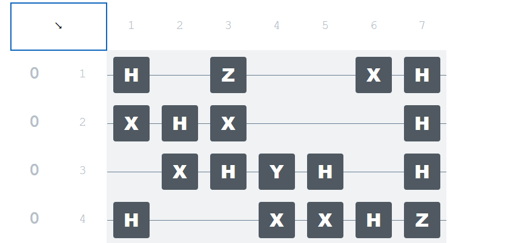

Nous avons adopté cette syntaxe de base qui facilite grandement la modélisation, tout en intégrant davantage de fonctionnalités. Parmi celles-ci, on retrouve les opérations de rotation ainsi que la construction empirique des fonctions abordées précédemment.

La syntaxe s’apparente à un tableau, où chaque ligne représente une séquence d’opérations appliquées au qubit correspondant.

Dans les circuits quantiques, les espaces entre opérations correspondent à des opérateurs identité, notés $I$. Ceux-ci permettent de structurer visuellement le circuit de manière ordonnée et claire.

## Une modélisation simple des valeurs dans le circuit quantique

Pour notre simulateur et afin de simplifier la modélisation, on fixe $V$ comme un vecteur de valeurs $v$ sous la forme $[v_0, v_1, ... v_n]$.

Dans notre cas, une valeur $v$ est une valeur qui regroupe tous les types de valeurs que l'on peut introduire dans le circuit quantique.

Pour être plus claire nous repartons de cette modélisation :

$$ |0⟩——[W^{(2)}(\Theta)]———[S(x)]———[W^{(1)}(\Theta)]——> M \\ $$

si on décompose toutes les formules en retournant bas niveau on aura :

$$ |0⟩——[RZ(\theta_0)]——[RY(\theta_1)]——[RZ(\theta_2)]——[RX(x)]——[RZ(\theta'_0)]——[RY(\theta'_1)]——[RZ(\theta'_2)]——> M \\ $$

Avec notre syntaxe évoluée, on obtient donc :

[output not shown]

Et en utilisant notre simulateur :

```python
from source.quantum_circuit import *

# Code de configuration

code  = """
RZ(v)-RY(v)-RZ(v)-RX(v)-RZ(v)-RY(v)-RZ(v)
"""

# Construction du circuit avec son affichage

qc = quantum_circuit(code)
qc.draw(True)
```

```
--- Circuit ---
|0⟩—[RZ(0j)]—[RY(0j)]—[RZ(0j)]—[RX(0j)]—[RZ(0j)]—[RY(0j)]—[RZ(0j)]—> M
```

Un autre aspect pratique de notre simulation, c'est la représentativité de la série de calculs.

Pendant une itération, suivre les valeurs injectées dans le modèle et les valeurs des qubits après modification se révèle fondamental, nous l'avons implémenté et en voici un exemple :

```python
qc.replace_values([0.2, 0.5,0.6,5, 0.3, 0.6, 0.3])
qc.apply_circuit()
```

```
[array([-0.45716642+0.50645903j, -0.4240708 -0.59553517j])]
```

Les valeurs que l'on injecte dans le modèle sont un simple vecteur de valeurs et le resteront pour simplifier l'encodage des données ; le modèle en question ne va pas opérer avec des matrices de certaine taille à encoder, mais une simple liste qui va remplacer, occurrence par occurrence, toutes les valeurs par celles que l'on encode dans la carte pour simplifier la gestion.

# Un simulateur avec une conception de porte empirique

Dans notre simulation, les portes sont représentées sous forme de dictionnaire avec une fonction qui leur est associée.

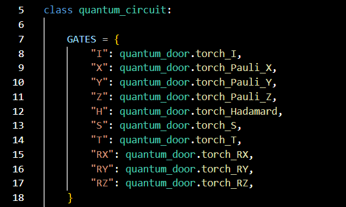

Cette méthode de configuration des portes nous permet aisément de construire des super-portes incluant des sous-portes.

Nous allons refaire la démarche de généralisation empirique des portes que nous avons effectuée au début de cette section pour illustrer notre propos.

```python
# Pour assurer un bon fonctionnement du programme, on supprime les nouvelles au début pour éviter
# la saturation du dictionnaire avec des exécutions consécutives dans le notebook.

quantum_circuit.clear_gates()

# On définit G(X)

quantum_circuit.add_door("G", "RX(v)")

# On définit S(X)

quantum_circuit.add_door("S", "G(v)")

# On définit W(theta)

quantum_circuit.add_door("W", "RZ(v)-RY(v)-RZ(v)")


quantum_circuit.display_gates()

code  = """
W(v,v,v)-G(v)-W(v,v,v)
"""

# Construction du circuit avec son affichage

qc = quantum_circuit(code)
qc.draw(general=True)

qc.replace_values([0.2, 0.5,0.6,5, 0.3, 0.6, 0.3])
qc.apply_circuit()
```

```
| Name     | Code/Function                                 |
|----------|-----------------------------------------------|
| I        | quantum_door.I                                |
| *        | quantum_door.I                                |
| X        | quantum_door.Pauli_X                          |
| Y        | quantum_door.Pauli_Y                          |
| Z        | quantum_door.Pauli_Z                          |
| H        | quantum_door.Hadamard                         |
| S        | composite_gate                                |
| T        | quantum_door.T                                |
| RX       | quantum_door.RX                               |
| RY       | quantum_door.RY                               |
| RZ       | quantum_door.RZ                               |
| CNOT     | quantum_entangling_gate.CNOT                  |
| CX       | quantum_entangling_gate.CNOT                  |
| CCNOT    | quantum_entangling_gate.CCNOT                 |
| CCX      | quantum_entangling_gate.CCNOT                 |
| CZ       | quantum_entangling_gate.CZ                    |
| SWAP     | quantum_entangling_gate.SWAP                  |
| ISWAP    | quantum_entangling_gate.ISWAP                 |
| CSWAP    | quantum_entangling_gate.CSWAP                 |
| GHZ      | quantum_entangling_gate.GHZ                   |
| G        | composite_gate                                |
| W        | composite_gate                                |


--- Circuit ---
|0⟩—[W(0j, 0j, 0j)]—[G(0j)]—[W(0j, 0j, 0j)]—> M
```

```
[array([-0.45716642+0.50645903j, -0.4240708 -0.59553517j])]
```

# Les circuits avec plusieurs qubits

Notre simulation a la capacité de modéliser plusieurs qubits dans le circuit et de leur faire subir des opérations complexes.

On va réutiliser le code que nous avons mis en place pour la représentation sur le site, mais de la manière suivante :

```python
# Pour assurer un bon fonctionnement du programme, on supprime les nouvelles au début pour éviter
# la saturation du dictionnaire avec des exécutions consécutives dans le notebook.

quantum_circuit.clear_gates()



code  = """
H-I-Z-I-I-X-H
X-H-X-I-I-I-H
I-X-H-Y-H-I-H
H-I-I-X-X-H-Z
"""

# Construction du circuit avec son affichage

qc = quantum_circuit(code)
qc.draw(general=True)

qc.apply_circuit()
```

```
--- Circuit ---
|0⟩—[H]—————[Z]——————————⬤——[H]—> M

|1⟩——⬤——[H]——⬤——————————————[H]—> M

|2⟩——————⬤——[H]—[Y]—[H]—————[H]—> M

|3⟩—[H]——————————⬤———⬤——[H]—[Z]—> M
```

```
[array([ 0.+0.j, -1.+0.j]),
 array([ 0.+0.j, -1.+0.j]),
 array([0.-0.70710678j, 0.-0.70710678j]),
 array([1.+0.j, 0.+0.j])]
```